# Wrangle and Analyze WeRateDogs Data

## Introduction

The dataset that I wrangled, analyzed, and visualized is the tweet archive of Twitter user @dog_rates, also known as WeRateDogs. WeRateDogs is a Twitter account that rates people's dogs with a humorous comment about the dog. These ratings almost always have a denominator of 10. The numerators, though? Almost always greater than 10. 11/10, 12/10, 13/10, etc. Why? Because "they're good dogs Brent." WeRateDogs has over 8.7 million followers as of June 15, 2020 and has received international media coverage.

WeRateDogs downloaded their Twitter archive and sent it to Udacity via email exclusively to use in this project. This archive contains basic tweet data (tweet ID, timestamp, text, etc.) for all 5000+ of their tweets as they stood on August 1, 2017.

[figure not shown]

Image via Boston Magazine

## Linear relationship betwwen favorite count vs retweet count

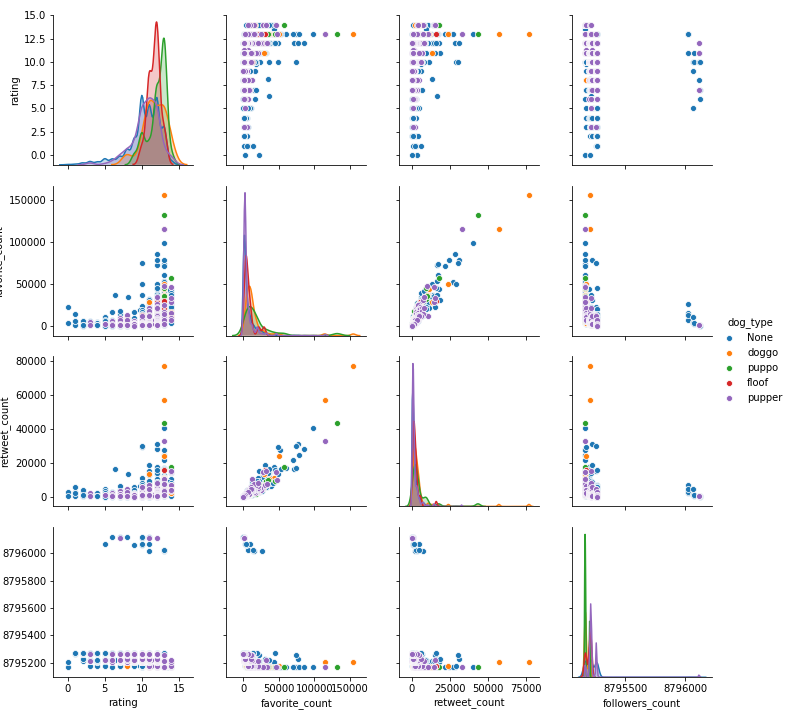

```python
from IPython.display import Image
Image(filename='1.png')
```

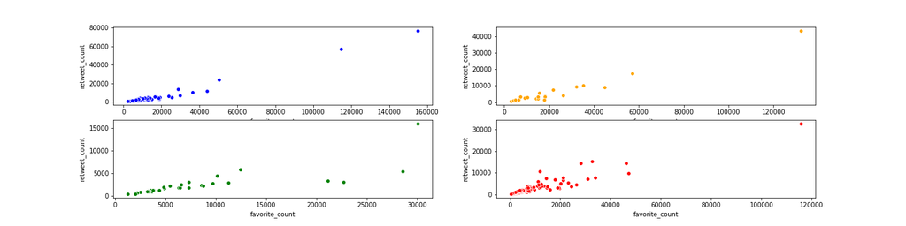

```python
Image(filename='2.png')
```

From the pairplots, the positive strong relationship between retweet_count and favorite_count was observed, which was assumed that there are lots of people who can retweet whatever they liked, expressing.

# Highest count breed has the highest different variables?

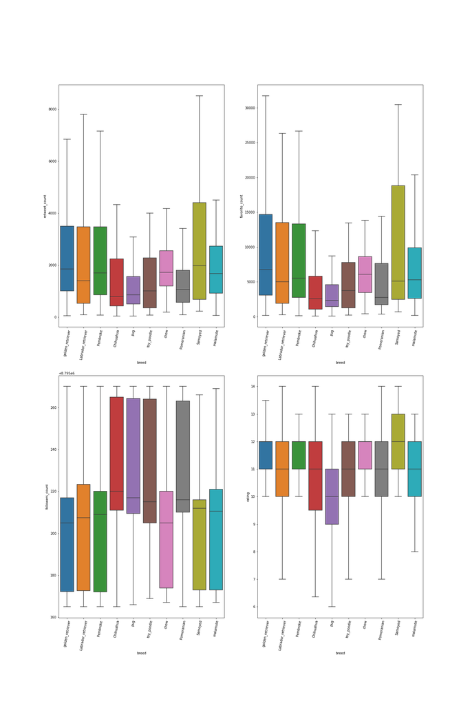

```python
Image(filename='3.png')
```

The four different box plots show that even the top 10 highest number of dog breeds posted in the tweet dataset is not equal to the ones of follower count, retweet count, and favorite count. They have different characteristics on each variable.

# Popularity on Any specific Dog type and Dog breed

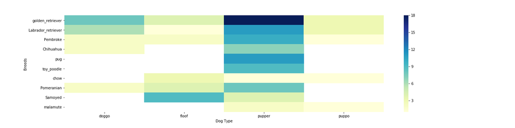

```python
Image(filename='4.png')
```

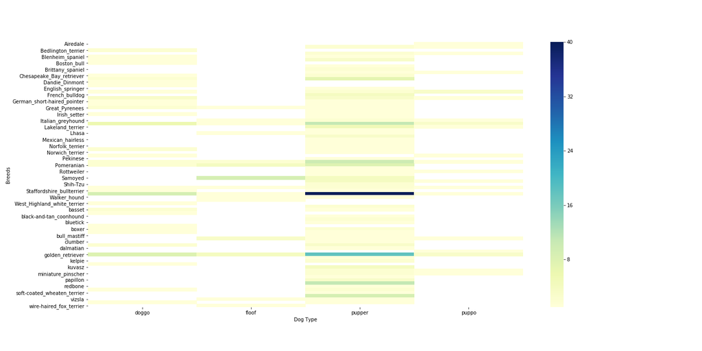

```python
Image(filename='5.png')
```

On the heatmap, we can easily compare the count of dog breeds vs dog type. When compared with the top 10 highest counts of dog breeds, the golden retriever as a dog breed and pupper as a dog type have the highest count overall breeds and dog types. However, when compared to all types of breeds and dog types, Staffordshire bullterrier as a dog breed and pupper as a dog type are the highest.